# DAAD

The German Academic Exchange Service

Dr. Daniel Jach

School of Foreign Languages, Southwest Jiaotong University, Chengdu

August 4, 2025

## A Global Academic Support Network

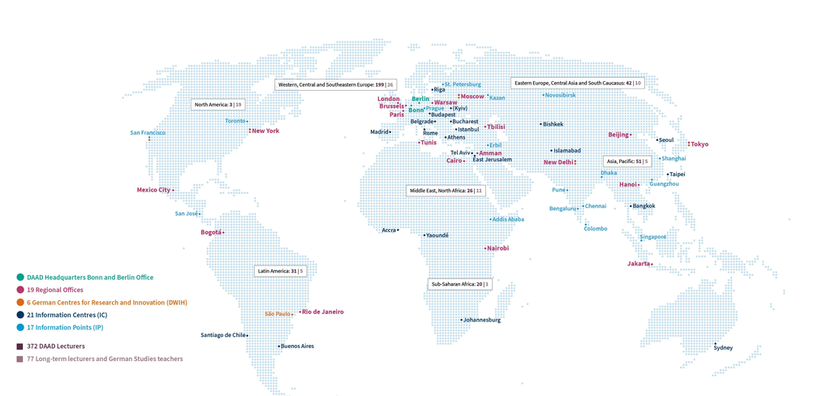

## The DAAD is …

- the world’s largest funding organisation for international exchange, and devoted to internationalising the academic system.
- the independent organisation of German higher education institutions and their student bodies.
- an experienced intermediary between higher education systems with a worldwide network.

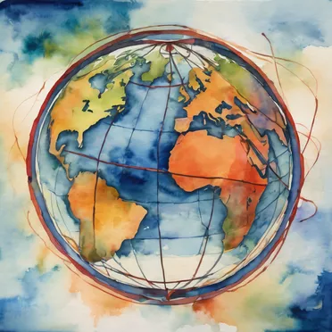

## DAAD on a Spreadsheet

[figure not shown]

1.73 million outgoing students since 1950

[figure not shown]

1.19 million incoming students since 1950

[figure not shown]

3,580 projects funded in 2022

[figure not shown]

372 lecturers at universities worldwide in 2022

[figure not shown]

57 DAAD offices worldwide in 2022

[figure not shown]

160 alumni associations worldwide in 2022

[figure not shown]

774.8 Mio. Euro annual budget in 2022

1,130 staff in Germany and worldwide in 2022

[figure not shown]

6 German Centres for Research and Innovation (DWIH) in 2022

## DAAD Funding in 2022

In total, the DAAD supported 140,873 grantees in 2022.

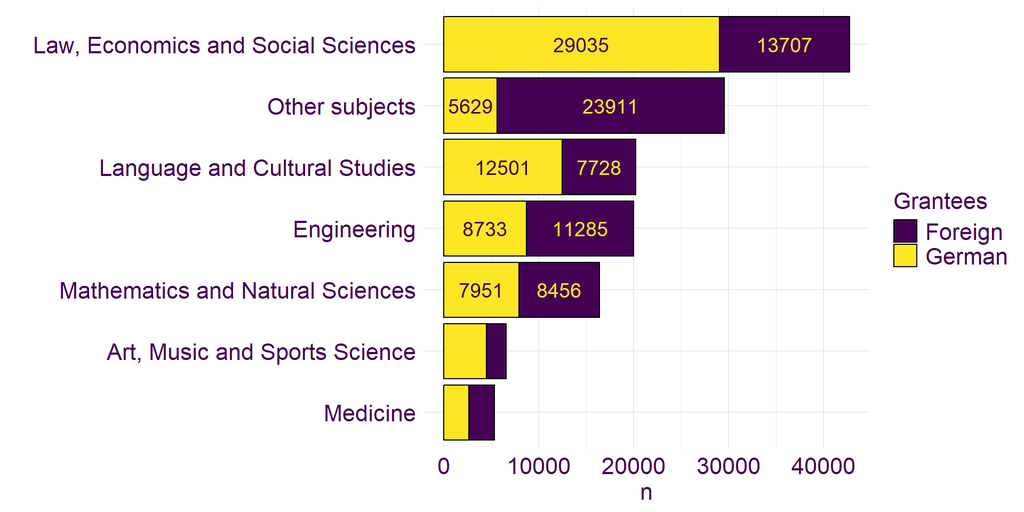

Number of grantees by subject

DAAD-Jahresbericht 2022, 131

## DAAD Strategy for 2025

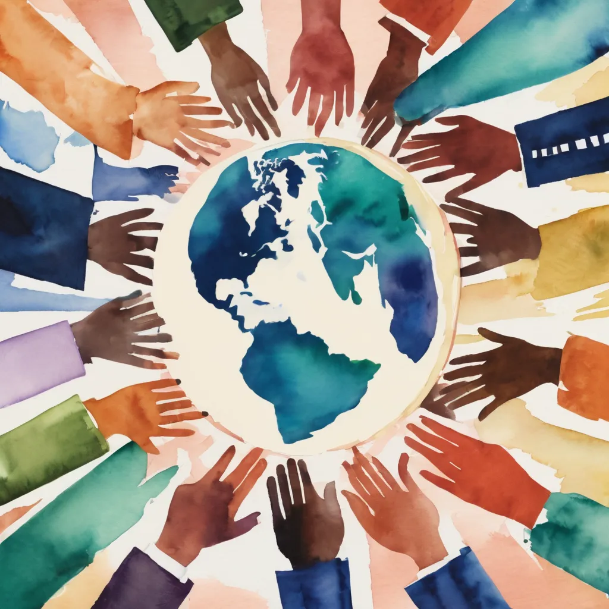

- Promote excellence and broaden perspectives of education and science through international exchange
- Enhance international collaboration for the benefit of science, industry and society
- Assume global responsibility and contribute to development and peace

## DAAD in China

- Since 1935 – DAAD Centre in Beijing – 1540 grantees from China, 296 grantees from Germany (2022)
- “Language and Practice in China” Scholarship for German graduates to gain China expertise
- Chinese-German University College (CDH) at Tongji University, Shanghai
- Development of the Rule of Law Dialogue (German Law in Asia) at Legal Institutes in Nanjing and Beijing

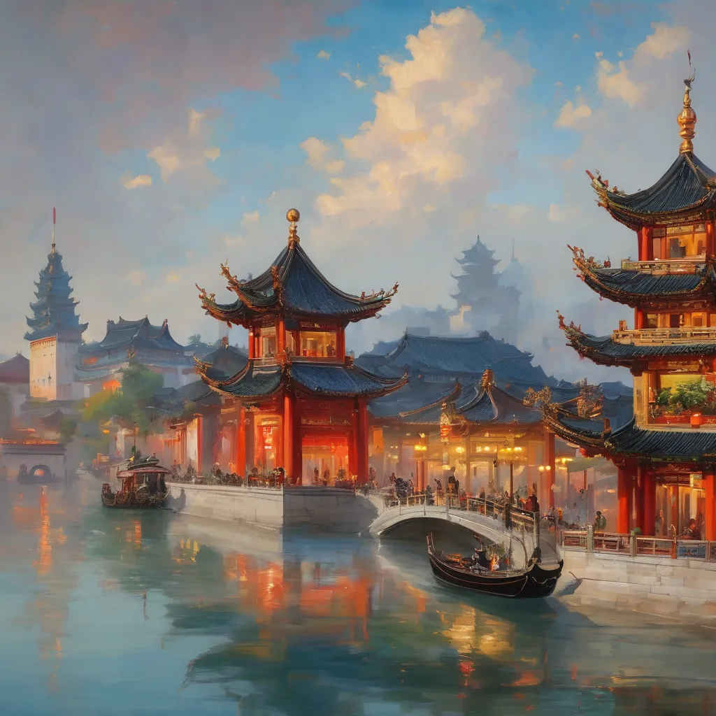

Länderbericht China kurz 2023, https://www.daad.de/de/laenderinformationen/asien/china/artikel-analysen/, April 13, 2024.

## DAAD Lectureships

- Since 1978, German lecturers have been teaching German as a foreign language, German literature, and regional studies at Chinese universities, as well as advising Chinese students on academics and studying abroad.

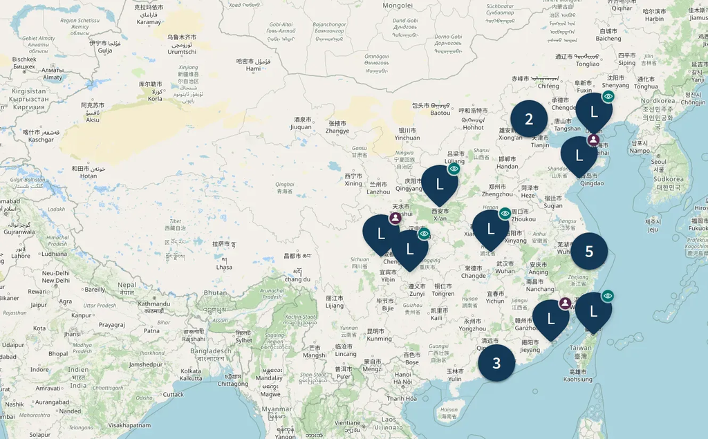

Currently 18 lectureships in Chongqing, Dalian, Guangzhou, Hangzhou, Hongkong, Beijing, Qingdao, Shanghai, Chengdu, Xiamen

- Take a look at the new [page flow website](https://pageflow.daad.de/lektorenprogramm#1647) with fancy image videos from China and abroad.

# Some Examples of Activities by DAAD Lecturers in China

## Didactics Workshop for Future Teachers

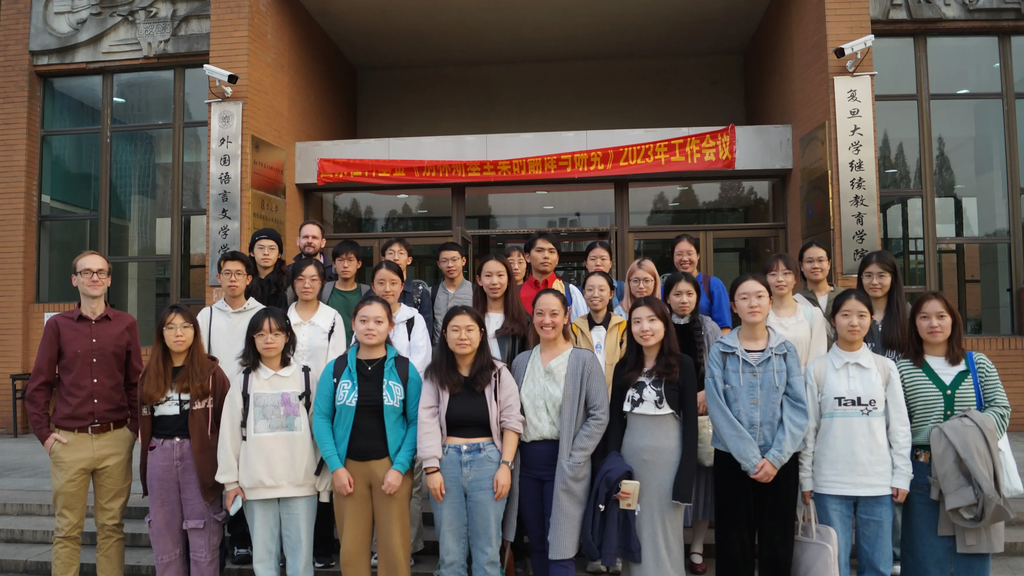

On the weekend of October 14th and 15th 2023, German students from several universities in Shanghai came to Fudan University to get an insight into what it means to work as a German teacher (by Daniel Simon and Melanie Späthe).

## German Culture Week

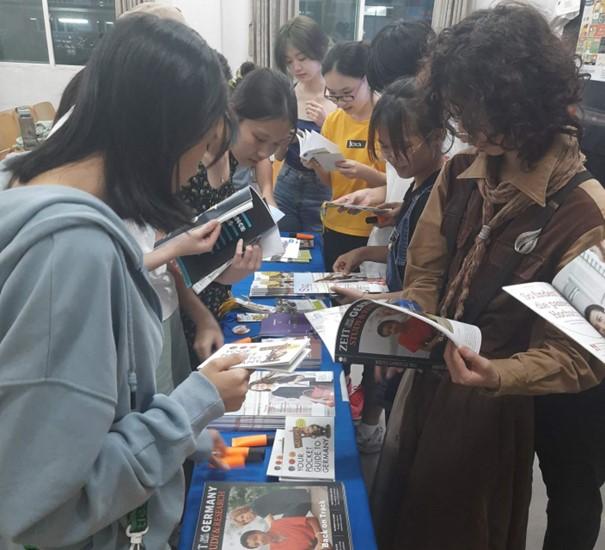

The first German Culture Week took place at the Guangdong University of Foreign Studies (GDUFS) from May 29 to June 4, 2023, offering students a varied program of workshops and lectures on art, film and literature (by Katharina Quicker).

## Career Prospects for German Majors

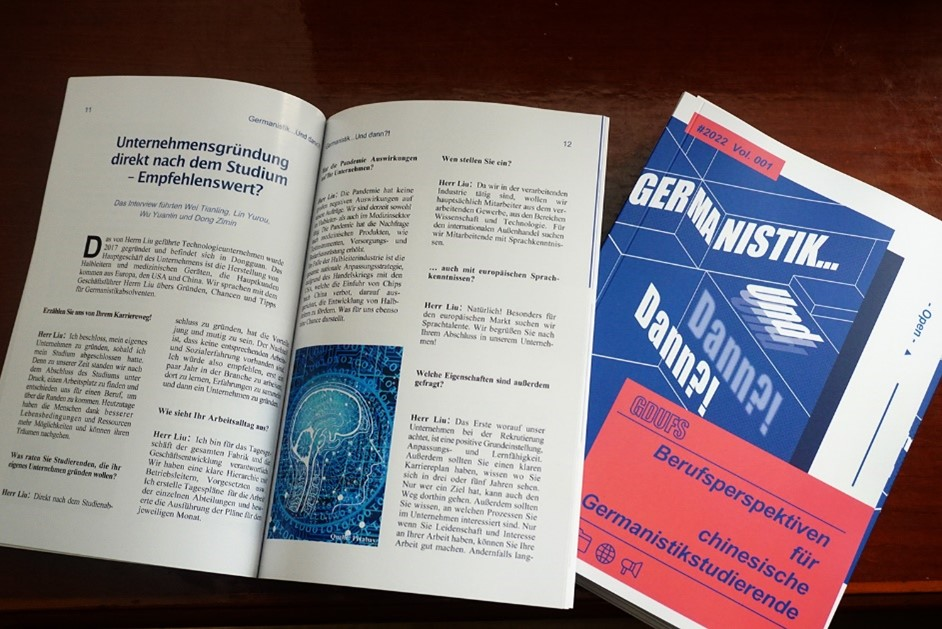

Whether as an overseas marketing manager, customs officer, insurance consultant or German teacher - the career prospects for Chinese graduates of German studies are varied, but not always clearly recognizable as such. Students of German Studies at the Guangdong University of Foreign Studies (GDUFS) interviewed professionals in the field who have studied German or who employ German graduates (by Katharina Quicker, 2022-2023). Click [here](https://pan.baidu.com/share/init?surl=pNgqHCMmKqvqREbyKW2MAg&pwd=1234) to download the booklet (password 1234).

## Advanced Didactics Training Workshop

[figure not shown]

Germanistik Südwest 2022 (“German Studies in the Southwest 2022”) was a three-day online event for advanced teachers of German, including lectures and workshops on the use of corpora in language teaching, online, October 28-30, 2022 (by Sabrina Stock, Sichuan International Studies University Chongqing, and Daniel Jach, Southwest Jiaotong University, Chengdu)

## Working and Living Abroad

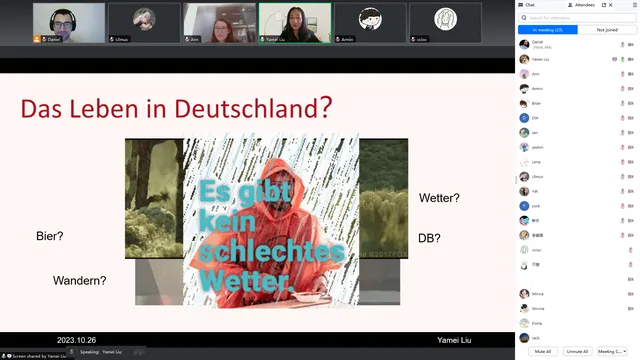

“Looking Back Forward” is an online series for students of German studies in China. The speakers are Chinese graduates of German studies who are now successful in academia, business or government service. They look back on their studies in China, the time after and their way from China to the world and talk about life and work in Germany and elsewhere (by Daniel Jach, Southwest Jiaotong University, Chengdu).

## Vocational Education Training Workshops

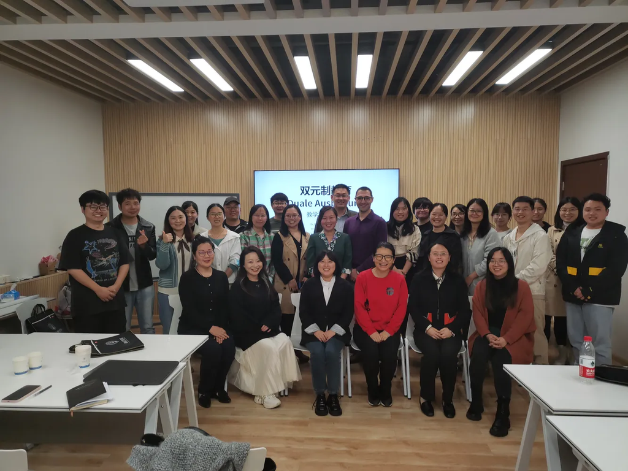

Workshop on the German vocational training system for Chinese vocational teachers at the School of Mechanical Engineering of Southwest Jiaotong University in Chengdu (06. and 08.11.2023). Teachers learned about the institutional structure of the German VET system and practiced an action-oriented teaching approach (by Daniel Jach, Dou Yangguang, and Lu Tao, Southwest Jiaotong University, Chengdu).

## Christmas Party

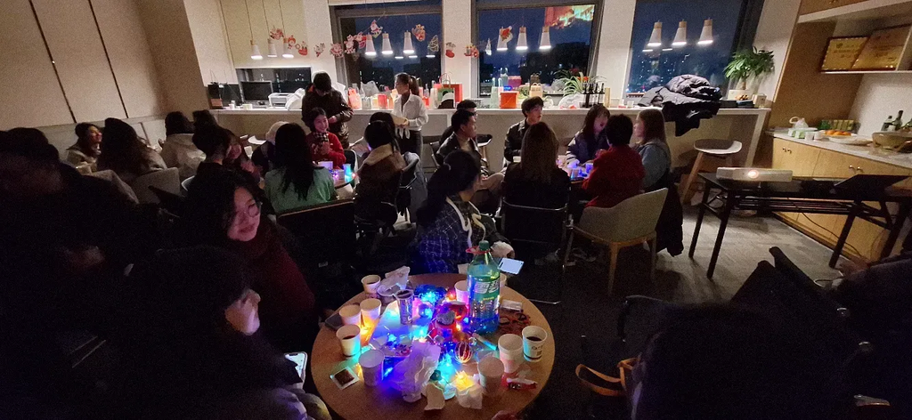

Christmas party at the Faculty Club of the School of Foreign Languages with the German speaking students of Southwest Jiaotong University, Chengdu (by Daniel Jach, Dou Yangguang, and Lu Tao, Southwest Jiaotong University, Chengdu).

## Get in Touch

If you have **any questions** about **Studying in Germany**, get in touch with your local DAAD lecturer or with the DAAD Office in Beijing.

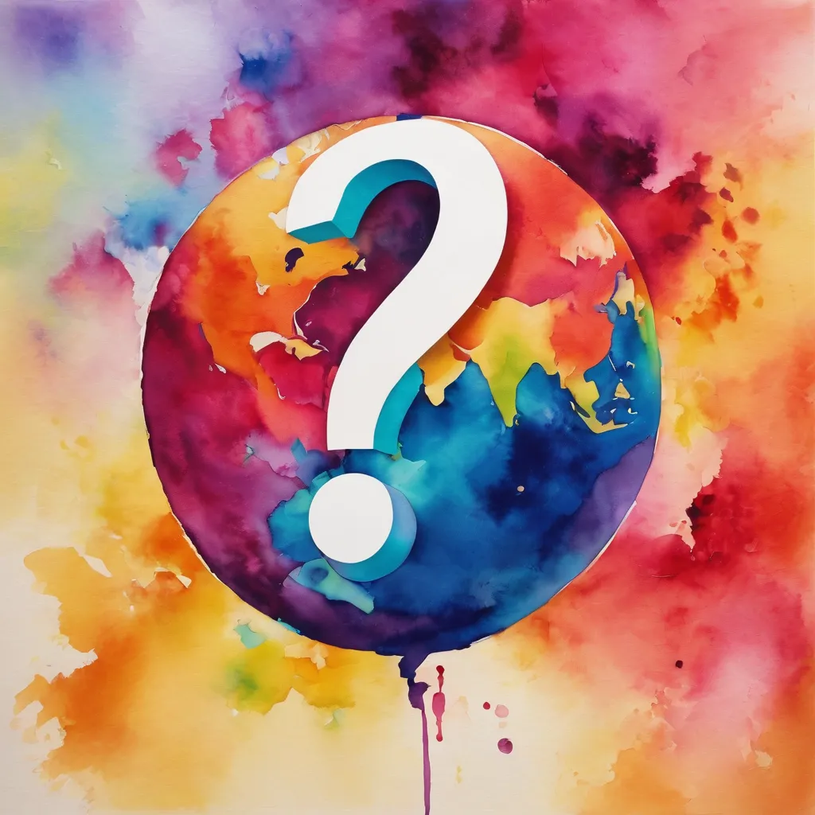

- What programs are available?
- Where can I go?
- What are the eligibility criteria?
- When can I apply?
- How do I finance my studies abroad?
- What support services are available?
- What is student life like?
- What are the visa requirements?
- What are the housing options?
- …

[figure not shown]

DAAD Lecturer

[figure not shown]

Beijing Office

## Thank you for your attention!

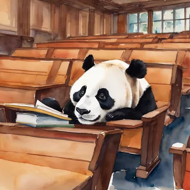

**Questions?**

[figure not shown]

**Slides online**